# Logistic Regression

## With Scikit-Learn

Logistic regression is a classification technique used when the response variable is categorical. It models the log-odds of the probability of an event occurring as a linear combination of input features. The model outputs probabilities and is commonly used for binary classification tasks.

### Use Cases

- Predicting customer churn, whether customers will stay or leave
- Modeling likelihood of purchase
- Determine characteristics of online ads that customer click
- Estimating likelihood of loan default
- Disease diagnosis

### Strengths

- Provides a probability of the prediction
- Coefficients help in evaluating feature influence
- Easy to interpret and communicate

### Weaknesses

- Assumes a linear relationship in the log-odds
- Less effective when there is a class imbalance
- Sensitive to multicollinearity, outliers, and missing data

## Overview

This note will demonstrate the use of Logistic Regression to predict likelihood that an iPad will sell based on its characteristics. This note will focus on the application of Scikit-Learn using the same data as the other note on Logistic Regression. Since the data used here is identical to the one used in the other note on Logistic Regression, discussion of data exploration is kept short. Please review the Linear Regression note with StatsModels before reviewing this note.

## Data Description

The original data consisting of eBay auctions for iPads was simplified and new variables derived. The goal of the analysis is to predict which iPad listed on eBay will be sold, a binary outcome. We have a number of pieces of information on each listing. Variables are described below.

1. UniqueID: Id
2. sold: Whether listed iPad sold (sold = 1) or not sold (sold = 0)
3. biddable = Whether this is an auction (biddable=1) or a sale with a fixed price (biddable=0).
4. startprice = The start price (in US Dollars) for the auction (if biddable=1) or the sale price (if biddable=0).
5. condition = The condition of the product (new, used, etc.)
6. cellular = Cellular connectivity for ipad (Cellular, No cellular or Unknown)
7. carrier = The cellular carrier for which the iPad is equipped (if cellular=1); listed as “None” if cellular=0
8. color = The color of the iPad - Black, Gold, Space Gray, Unknown or White
9. storage = The iPad’s storage capacity (in gigabytes) - Less than 128 GB, 128 GB or Unknown
10. productline = Model of iPad being sold
11. noDescription: Whether the posting item has a description or not
12. charCountDescription: Length of description in terms of number of characters
13. upperCaseDescription: Number of upper case letters in the Description
14. startprice_99end: Whether the startprice ends in 99 (startprice_99end = 1) or not (startprice_99end = 0)

## Read Data

```python
import numpy as np
import pandas as pd
```

```python
data = pd.read_csv('eBayClean.csv')
```

## Split Data

Evaluating a model using data to estimate it risks overfitting the model to the data used to build it. For this reason, it is best to evaluate the model using a different dataset. Since getting a fresh dataset for evaluating a model may be costly, time consuming and in some cases impossible, it is common to split the data into a train and test sample, estimating the model using the train and evaluating it using the test.

Let us start by splitting the data into a train and test sample such that 70% of the data is in the train sample.

```python
y = data.sold
X = data.drop(['UniqueID','sold'], axis = 1)
from sklearn.model_selection import train_test_split
X_train_raw, X_test_raw, y_train, y_test = train_test_split(X, y,
                                                            random_state=1031,
                                                            train_size=0.7,
                                                            stratify=y)
```

## Transform Data

```python
X_train_raw.info()
```

```
<class 'pandas.core.frame.DataFrame'>
Index: 1302 entries, 1510 to 1075
Data columns (total 12 columns):
 #   Column                Non-Null Count  Dtype
---  ------                --------------  -----
 0   biddable              1302 non-null   object
 1   startprice            1302 non-null   float64
 2   condition             1302 non-null   object
 3   cellular              1302 non-null   object
 4   carrier               526 non-null    object
 5   color                 1302 non-null   object
 6   storage               1302 non-null   object
 7   productline           1302 non-null   object
 8   noDescription         1302 non-null   object
 9   charCountDescription  1302 non-null   int64
 10  upperCaseDescription  1302 non-null   int64
 11  startprice_99end      1302 non-null   object
dtypes: float64(1), int64(2), object(9)
memory usage: 132.2+ KB
```

```python
#categorical_features = ['biddable','condition','cellular', 'carrier', 'color','storage','productline','noDescription','startprice_99end']
categorical_features = X_train_raw.select_dtypes('object').columns

X_train = pd.get_dummies(X_train_raw,
                         prefix_sep = '_',
                         columns = categorical_features,
                         drop_first = True)

X_test = pd.get_dummies(X_test_raw,
                         prefix_sep = '_',
                         columns = categorical_features,
                         drop_first = True)

X_test = X_test.reindex(columns=X_train.columns, fill_value=0)
X_train.head()
```

|  | startprice | charCountDescription | upperCaseDescription | biddable_not biddable | condition_new | condition_refurbished | condition_used | cellular_No cellular | cellular_Unknown | carrier_Sprint/T-Mobile | ... | productline_iPad 2 | productline_iPad 3 | productline_iPad 4 | productline_iPad Air 1/2 | productline_iPad mini | productline_iPad mini 2 | productline_iPad mini Retina | productline_iPad mini3 | noDescription_no description | startprice_99end_not a 99 ending |
| --- | --- | --- | --- | --- | --- | --- | --- | --- | --- | --- | --- | --- | --- | --- | --- | --- | --- | --- | --- | --- | --- |
| 1510 | 160.00 | 0 | 0 | True | False | False | True | True | False | False | ... | False | False | False | False | True | False | False | False | True | True |
| 576 | 279.00 | 99 | 1 | False | False | False | True | False | False | False | ... | False | False | False | True | False | False | False | False | False | True |
| 1468 | 100.00 | 99 | 58 | False | False | False | True | True | False | False | ... | False | False | False | False | True | False | False | False | False | True |
| 950 | 829.99 | 0 | 0 | True | True | False | False | False | False | False | ... | False | False | False | True | False | False | False | False | True | False |
| 435 | 500.00 | 95 | 5 | True | False | False | True | True | False | False | ... | False | False | False | True | False | False | False | False | False | True |

5 rows × 29 columns

## Explore Data

Exploration has been discussed in the note on logistic regression that used statsmodels, therefore it will not be discussed here.

```python
X_train.info()
```

```
<class 'pandas.core.frame.DataFrame'>
Index: 1302 entries, 1510 to 1075
Data columns (total 29 columns):
 #   Column                            Non-Null Count  Dtype
---  ------                            --------------  -----
 0   startprice                        1302 non-null   float64
 1   charCountDescription              1302 non-null   int64
 2   upperCaseDescription              1302 non-null   int64
 3   biddable_not biddable             1302 non-null   bool
 4   condition_new                     1302 non-null   bool
 5   condition_refurbished             1302 non-null   bool
 6   condition_used                    1302 non-null   bool
 7   cellular_No cellular              1302 non-null   bool
 8   cellular_Unknown                  1302 non-null   bool
 9   carrier_Sprint/T-Mobile           1302 non-null   bool
```

[output cut: 21 more lines]

```python
X_train.head()
```

|  | startprice | charCountDescription | upperCaseDescription | biddable_not biddable | condition_new | condition_refurbished | condition_used | cellular_No cellular | cellular_Unknown | carrier_Sprint/T-Mobile | ... | productline_iPad 2 | productline_iPad 3 | productline_iPad 4 | productline_iPad Air 1/2 | productline_iPad mini | productline_iPad mini 2 | productline_iPad mini Retina | productline_iPad mini3 | noDescription_no description | startprice_99end_not a 99 ending |
| --- | --- | --- | --- | --- | --- | --- | --- | --- | --- | --- | --- | --- | --- | --- | --- | --- | --- | --- | --- | --- | --- |
| 1510 | 160.00 | 0 | 0 | True | False | False | True | True | False | False | ... | False | False | False | False | True | False | False | False | True | True |
| 576 | 279.00 | 99 | 1 | False | False | False | True | False | False | False | ... | False | False | False | True | False | False | False | False | False | True |
| 1468 | 100.00 | 99 | 58 | False | False | False | True | True | False | False | ... | False | False | False | False | True | False | False | False | False | True |
| 950 | 829.99 | 0 | 0 | True | True | False | False | False | False | False | ... | False | False | False | True | False | False | False | False | True | False |
| 435 | 500.00 | 95 | 5 | True | False | False | True | True | False | False | ... | False | False | False | True | False | False | False | False | False | True |

5 rows × 29 columns

## Model 1: startprice

Examine the influence of “startprice” on whether an iPad sold or not.

### Fit Model

```python
from sklearn.linear_model import LogisticRegression
logit = LogisticRegression(max_iter=10000, random_state=1031)
logit.fit(X_train.loc[:,['startprice']], y_train)
```

```
LogisticRegression(max_iter=10000, random_state=1031)
```

### Predict

Logistic Regression generates a predicted probability for each level of the outcome. This can be mapped to a binary outcome by setting a probability threshold. The threshold used varies by domain and is generally determined by the cost of false negatives vs. false positives. In the absence such information, a default threshold of 0.5 is used.

Let us examine predicted proabilities of the first ten observations. The probability array includes predicted probability for each level of the outcome variable.

```python
y_pred_proba = logit.predict_proba(X_train.loc[:,['startprice']])
y_pred_proba[:10]
```

```
array([[0.46991303, 0.53008697],
       [0.67757012, 0.32242988],
       [0.36454752, 0.63545248],
       [0.99132865, 0.00867135],
       [0.91258114, 0.08741886],
       [0.62999945, 0.37000055],
       [0.69473264, 0.30526736],
       [0.96873406, 0.03126594],
       [0.5422884 , 0.4577116 ],
       [0.2186055 , 0.7813945 ]])
```

The predicted probability of an ipad selling can be converted to a binary outcome (0 or 1) by comparing to a threshold value of say, 0.5. This is also the default threshold used by .predict()

```python
(y_pred_proba[:,1]>0.5).astype('int')
```

```
array([1, 0, 1, ..., 1, 1, 1], shape=(1302,))
```

```python
y_pred = logit.predict(X_train.loc[:,['startprice']])
y_pred[:10]
```

```
array([1, 0, 1, 0, 0, 0, 0, 0, 0, 1])
```

Next, we will apply the Logistic Regression equation to predict the likelihood of selling an iPad with a startprice of $200.

```python
startprice_200 = pd.DataFrame({'startprice':[200]}) # ipad with a startprice of $200
ipad_200_proba = logit.predict_proba(startprice_200)[:,1]
ipad_200_pred = logit.predict(startprice_200)
print('Predicted probability of selling a $200 iPad: ', ipad_200_proba)
print('Prediction of whether a $200 iPad will sell: ', ipad_200_pred)
```

```
Predicted probability of selling a $200 iPad:  [0.4576936]
Prediction of whether a $200 iPad will sell:  [0]
```

### Performance

Model predictions can be summarized into a confusion matrix or classification table. Here are some commonly used metrics to evaluate model performance.

- Accuracy-based metrics
  - Accuracy or Misclassification rate (= 1-Accuracy)
- Accuracy focused on type of error. All errors are bad, some are worse.
  - Precision: Among everything predicted Positive, how many were actually Positive?
  - Recall (or Sensitivity): Among everything that was truly Positive, how many were actualy Positive?
  - Specificity: Among everything that was truly Negative, how many were actually Negative?
- Performance independent of cutoff value
  - Area under the ROC curve (AUC)

```python
from sklearn.metrics import confusion_matrix
confusion_matrix(y_train, y_pred)
```

```
array([[498, 202],
       [172, 430]])
```

```python
from sklearn.metrics import accuracy_score, precision_score, recall_score, roc_auc_score
accuracy = accuracy_score(y_train, y_pred)
precision = precision_score(y_train, y_pred)
sensitivity_or_recall = recall_score(y_train, y_pred)
auc = roc_auc_score(y_train, y_pred_proba[:,1])

pd.Series(data = [accuracy, precision, sensitivity_or_recall, auc],
          index=['Accuracy','Precision', 'Sensitivity or Recall', 'Area Under the Curve'])
```

```
Accuracy                 0.712750
Precision                0.680380
Sensitivity or Recall    0.714286
Area Under the Curve     0.787730
dtype: float64
```

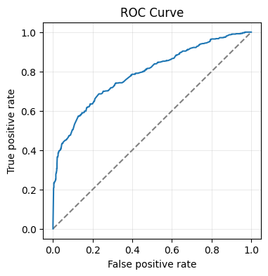

```python
import matplotlib.pyplot as plt
from sklearn.metrics import roc_curve
plt.figure(figsize=(4, 4))
fpr, tpr, thresholds = roc_curve(y_train, y_pred_proba[:,1])
plt.plot([0, 1], [0, 1], color='gray', linestyle='--')
plt.plot(fpr, tpr, label='ROC')
plt.xlabel("False positive rate")
plt.ylabel("True positive rate")
plt.title('ROC Curve')
plt.grid(True, linewidth = 0.5, alpha = 0.4)
plt.show()
```

## Model 2: condition

Examine the influence of “condition” on whether an iPad sold or not.

### Fit Model

iPads are characterized by four conditions, which are represented by three dummy variables.

```python
X_train.columns[X_train.columns.str.contains('condition')]
```

```
Index(['condition_new', 'condition_refurbished', 'condition_used'], dtype='object')
```

```python
logit = LogisticRegression(max_iter=10000, random_state=1031)
logit.fit(X_train.loc[:,['condition_new', 'condition_refurbished','condition_used']], y_train)
```

```
LogisticRegression(max_iter=10000, random_state=1031)
```

### Predict

Let us examine predicted probailities of an iPad selling and the predicted class.

```python
y_pred_proba = logit.predict_proba(X_train.loc[:,['condition_new', 'condition_refurbished','condition_used']])
y_pred = logit.predict(X_train.loc[:,['condition_new', 'condition_refurbished','condition_used']])

pd.DataFrame({'predicted_probability':y_pred_proba[:,1],
              'predicted class': y_pred}).head(10)
```

|  | predicted_probability | predicted class |
| --- | --- | --- |
| 0 | 0.506398 | 1 |
| 1 | 0.506398 | 1 |
| 2 | 0.506398 | 1 |
| 3 | 0.320969 | 0 |
| 4 | 0.506398 | 1 |
| 5 | 0.506398 | 1 |
| 6 | 0.320969 | 0 |
| 7 | 0.320969 | 0 |
| 8 | 0.506398 | 1 |
| 9 | 0.325136 | 0 |

Now, let us predict the probability of sale (sold=1) for an ipad in “new” condition.

```python
condition_new = pd.DataFrame({'condition_new':[True],
                              'condition_refurbished': [False],
                               'condition_used':[False]})
logit.predict_proba(condition_new)
```

```
array([[0.67903112, 0.32096888]])
```

### Performance

```python
from sklearn.metrics import confusion_matrix
confusion_matrix(y_train, y_pred)
```

```
array([[242, 458],
       [112, 490]])
```

```python
from sklearn.metrics import accuracy_score, precision_score, recall_score, roc_auc_score
accuracy = accuracy_score(y_train, y_pred)
precision = precision_score(y_train, y_pred)
sensitivity_or_recall = recall_score(y_train, y_pred)
auc = roc_auc_score(y_train, y_pred_proba[:,1])

pd.Series(data = [accuracy, precision, sensitivity_or_recall, auc],
          index=['Accuracy','Precision', 'Sensitivity or Recall', 'Area Under the Curve'])
```

```
Accuracy                 0.562212
Precision                0.516878
Sensitivity or Recall    0.813953
Area Under the Curve     0.589786
dtype: float64
```

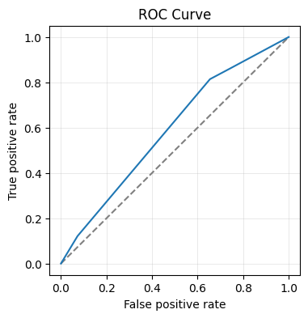

```python
import matplotlib.pyplot as plt
from sklearn.metrics import roc_curve
plt.figure(figsize=(4, 4))
fpr, tpr, thresholds = roc_curve(y_train, y_pred_proba[:,1])
plt.plot([0, 1], [0, 1], color='gray', linestyle='--')
plt.plot(fpr, tpr, label='ROC')
plt.xlabel("False positive rate")
plt.ylabel("True positive rate")
plt.title('ROC Curve')
plt.grid(True, linewidth = 0.5, alpha = 0.4)
plt.show()
```

## Model 3: All Predictors

### Fit Model

```python
logit = LogisticRegression(max_iter=10000,random_state=1031)
logit.fit(X_train, y_train)
```

```
LogisticRegression(max_iter=10000, random_state=1031)
```

### Predict

```python
y_pred = logit.predict(X_train)
y_pred_proba = logit.predict_proba(X_train)
y_pred_test = logit.predict(X_test)
y_pred_proba_test = logit.predict_proba(X_test)
```

### Performance: Train Sample

```python
from sklearn.metrics import confusion_matrix
confusion_matrix(y_train, y_pred)
```

```
array([[589, 111],
       [168, 434]])
```

```python
from sklearn.metrics import accuracy_score, precision_score, recall_score, roc_auc_score
accuracy = accuracy_score(y_train, y_pred)
precision = precision_score(y_train, y_pred)
sensitivity_or_recall = recall_score(y_train, y_pred)
auc = roc_auc_score(y_train, y_pred_proba[:,1])

pd.Series(data = [accuracy, precision, sensitivity_or_recall, auc],
          index=['Accuracy','Precision', 'Sensitivity or Recall', 'Area Under the Curve'])
```

```
Accuracy                 0.785714
Precision                0.796330
Sensitivity or Recall    0.720930
Area Under the Curve     0.857538
dtype: float64
```

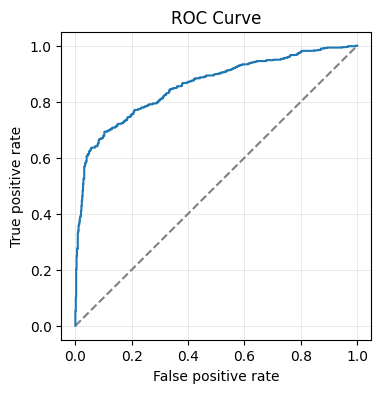

```python
import matplotlib.pyplot as plt
from sklearn.metrics import roc_curve
plt.figure(figsize=(4, 4))
fpr, tpr, thresholds = roc_curve(y_train, y_pred_proba[:,1])
plt.plot([0, 1], [0, 1], color='gray', linestyle='--')
plt.plot(fpr, tpr, label='ROC')
plt.xlabel("False positive rate")
plt.ylabel("True positive rate")
plt.title('ROC Curve')
plt.grid(True, linewidth = 0.5, alpha = 0.4)
plt.show()
```

### Performance: Test Sample

Finally, let us examine model performance on the test sample.

```python
from sklearn.metrics import confusion_matrix
confusion_matrix(y_test, y_pred_test)
```

```
array([[254,  47],
       [ 62, 196]])
```

```python
from sklearn.metrics import accuracy_score, precision_score, recall_score, roc_auc_score
accuracy = accuracy_score(y_test, y_pred_test)
precision = precision_score(y_test, y_pred_test)
sensitivity_or_recall = recall_score(y_test, y_pred_test)
auc = roc_auc_score(y_test, y_pred_proba_test[:,1])

pd.Series(data = [accuracy, precision, sensitivity_or_recall, auc],
          index=['Accuracy','Precision', 'Sensitivity or Recall', 'Area Under the Curve'])
```

```
Accuracy                 0.805009
Precision                0.806584
Sensitivity or Recall    0.759690
Area Under the Curve     0.858546
dtype: float64
```

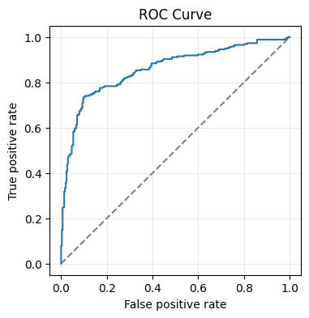

```python
import matplotlib.pyplot as plt
from sklearn.metrics import roc_curve
plt.figure(figsize=(4, 4))
fpr, tpr, thresholds = roc_curve(y_test, y_pred_proba_test[:,1])
plt.plot([0, 1], [0, 1], color='gray', linestyle='--')
plt.plot(fpr, tpr, label='ROC')
plt.xlabel("False positive rate")
plt.ylabel("True positive rate")
plt.title('ROC Curve')
plt.grid(True, linewidth = 0.5, alpha = 0.4)
plt.show()
```

## Summary

In this note, we examined implementation of Logistic Regression using Scikit-Learn. The focus of this note was Prediction. We examined logit models with

- one numeric feature
- one categorical feature
- multiple features

This file was generated using Python 3.13.5 on Windows 10 with the following libraries: matplotlib 3.10.3, numpy 2.3.1, pandas 2.3.0, scikit-learn 1.7.1